# June_Walkthrough

### 1. July and August in Oxford

- Lease up
- Saving money for summer
- Moving into Wentworth in September

### 2. Wolverine Interview

- Good experience but not that interesting...
- Missed on linear algebra exercise

> Let ( A ) be a 3×3 matrix such that $ A^3 = 0 $ but $A \ne 0 $.  
> What are the possible ranks of ( A )?
- Didn't recall that nilpotent matrices have rank strictly less than their size
- Correct answer: possible ranks are **1 or 2** (never 3, never 0 unless A = 0)

### 3. Santander Interview

- Risk management
- This week

### 4. Thesis Chapter

We assume that:

- A latent belief distribution exists:
  $$ X \sim \text{Beta}(\alpha, \beta) $$
- This represents the full spectrum of trader beliefs over possible outcomes.

### 1. Filtered Histogram (Observed Standing Orders)

- We observe standing (unmatched) orders from the order book in a snapshot.
- We apply a wide price filter: $$ [\text{midpoint} - \delta, \ \text{midpoint} + \delta] $$
- This creates a filtered dataset of visible standing orders.
- We compute a histogram: $$ \text{Density at } p_i = \frac{\text{Size}_i}{\sum \text{Size}} $$

### 2. Filtered Beta Fit (Observed Distribution)

- We treat the price histogram as a proxy for the **filtered distribution** of beliefs.
- We sample from this histogram and fit a Beta distribution: $$ \hat{\alpha}_{\text{filt}}, \hat{\beta}_{\text{filt}} \leftarrow \texttt{scipy.stats.beta.fit()} $$
- This filtered Beta approximates what we *observe* directly in the order book: $$ \text{Filtered Beta: } \text{Beta}(\hat{\alpha}_{\text{filt}}, \hat{\beta}_{\text{filt}}) $$

### 3. Rejection Beta (Latent Distribution)

- We assume that standing orders result from traders whose beliefs lie **outside the bid-ask spread**.
- The spread thus defines a **rejection region**: $$ \text{Reject if } p \in [\text{best bid}, \text{best ask}] $$
- The observed filtered distribution is a **truncated sample** from the latent Beta.
- To reverse this truncation, we build a sharpened "rejection" Beta: $$ \hat{\alpha}_{\text{rej}} = \hat{\alpha}_{\text{filt}} \cdot s \cdot (1 + 0.1 \cdot I) \\ \hat{\beta}_{\text{rej}} = \hat{\beta}_{\text{filt}} \cdot s \cdot (1 - 0.1 \cdot I) $$ where:
  - $s = \min(30, \max(1.5, \frac{0.25}{\text{spread}}))$ controls sharpness
  - $I = \left( \frac{\text{bid size}}{\text{total size}} - 0.5 \right) \cdot 2$ adjusts skew based on size imbalance
- This gives us a candidate for the full latent distribution: $$ \text{Rejection Beta: } \text{Beta}(\hat{\alpha}_{\text{rej}}, \hat{\beta}_{\text{rej}}) $$

### 4. Time Series + Granger Causality

- We repeat this process over many snapshots.
- For each time $t$, extract:
  - $p(t)$: Midpoint (price, i.e., latent mean)
  - $m_{\text{obs}}(t)$: Truncated mean from histogram
  - $c(t) = \hat{\alpha}_{\text{rej}} + \hat{\beta}_{\text{rej}}$
- Fit a VAR($k$) model to these time series.
- Run Granger causality tests:
  - Does $m_{\text{obs}}(t-1)$ help predict $p(t)$?
  - Does $c(t-1)$ help predict $p(t)$?
  - Do price shifts lead $c(t)$?

### Interpretation

- **Filtered Beta** = What we observe directly in the book (truncated beliefs)
- **Rejection Beta** = Inferred latent belief distribution
- **Concentration $c(t)$** = Strength of consensus
- Granger tests: assess whether **order book shape** anticipates **future market price changes**.

### Granger Causality Test Results (10% Threshold)

| Causal Direction | Test Statistic | p-value | Conclusion |
| --- | --- | --- | --- |
| mu_latent → mu_filtered | 1.676 | 0.102 | ⚠️ Marginal (10% level) |
| mu_latent → mu_rejection | 1.847 | 0.067 | ✅ Granger-causes |
| mu_filtered → mu_latent | 3.604 | 0.001 | ✅ Granger-causes |
| mu_rejection → mu_filtered | 3.351 | 0.001 | ✅ Granger-causes |

**Interpretation:**

- All three directions *except* `mu_latent → mu_filtered` show Granger causality at the 10% level.
- The system is dynamically interconnected and can be modeled as such for forecasting.

## Visible Market Orders Predict Trader Beliefs

We estimate three belief distributions from the order book:

- **Latent**: what traders actually believe.
- **Filtered**: what shows up as standing orders.
- **Rejection**: how traders strategically place orders under spread and risk constraints.

In short, even though standing orders are filtered and strategic, they still help forecast what traders really think — and should be modeled together.

### Example

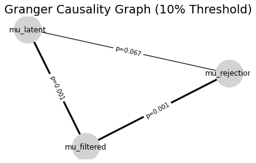

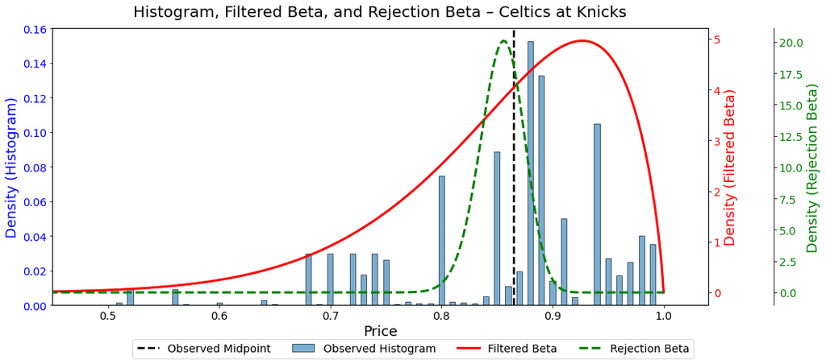

|  | Timestamp | mu_latent | mu_filtered | mu_rejection | VWAP | midpoint | alpha_latent | beta_latent | alpha_filtered | beta_filtered | spread | imbalance |
| --- | --- | --- | --- | --- | --- | --- | --- | --- | --- | --- | --- | --- |
| 0 | 2025-05-07 23:01:58.400 | 0.625376 | 0.855487 | 0.845675 | 0.854918 | 0.805 | 18.482495 | 11.071699 | 10.752440 | 1.816357 | 0.01 | 0.307041 |
| 1 | 2025-05-07 23:04:09.472 | 0.576473 | 0.839032 | 0.829218 | 0.838110 | 0.805 | 21.793207 | 16.011171 | 12.180073 | 2.336736 | 0.01 | 0.322703 |
| 2 | 2025-05-07 23:06:20.544 | 0.591814 | 0.839278 | 0.827367 | 0.838020 | 0.795 | 19.911925 | 13.733658 | 10.991775 | 2.104927 | 0.01 | 0.285667 |
| 3 | 2025-05-07 23:08:31.616 | 0.618805 | 0.843165 | 0.831037 | 0.840331 | 0.805 | 14.973514 | 9.223946 | 8.474889 | 1.576396 | 0.01 | 0.277719 |
| 4 | 2025-05-07 23:10:42.688 | 0.810207 | 0.848598 | 0.846177 | 0.845014 | 0.810 | 10.172214 | 2.382861 | 5.719651 | 1.020468 | 0.02 | 0.453198 |

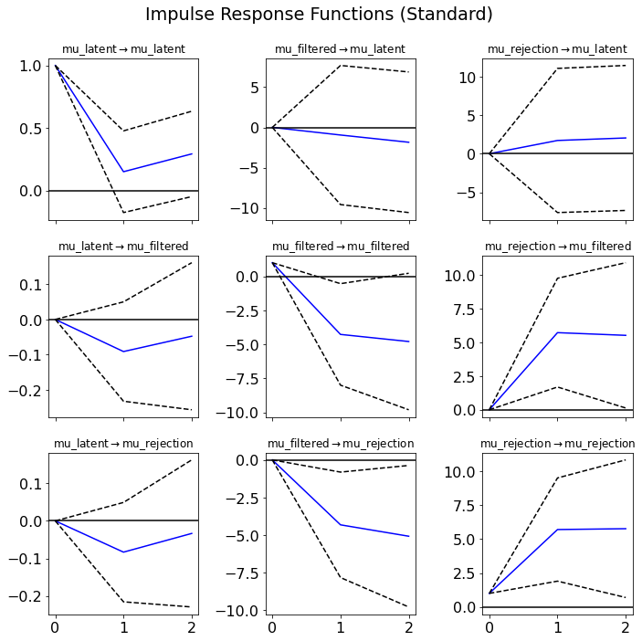

## Estimation Procedure

We estimate the latent belief distribution behind a prediction market order book using a three-stage Beta fitting pipeline.

### Step 1: Histogram-Based Fit (Filtered Beta)

- Group visible limit orders by price, summing size at each level.
- Normalize sizes to construct a discrete density.
- Approximate a sample by repeating prices proportional to density.
- Fit a Beta distribution on $[0,1]$ using `scipy.stats.beta.fit` with `floc=0`, `fscale=1`.

This yields:

$$ \text{Filtered: } \hat{\alpha}, \hat{\beta} $$

### Step 2: Rejection Sharpening (Rejection Beta)

- Compute spread: $\text{spread} = \text{ask}_{\min} - \text{bid}_{\max}$
- Compute imbalance: $z = \frac{\text{bid size}}{\text{bid + ask size}}$, normalized as $z' = (z - 0.5) \cdot 2$
- Define sharpening multiplier:

$$ \text{sharp} = \min(sharpness~factor,\ \max(1.5,\ 0.25 / \text{spread})) $$

- Apply sharpening and skew:

$$ \alpha_r = \hat{\alpha} \cdot \text{sharp} \cdot (1 + 0.1 z') \\ \beta_r = \hat{\beta} \cdot \text{sharp} \cdot (1 - 0.1 z') $$

This defines the **rejection filter distribution** used to simulate order visibility.

### Step 3: Inverse Simulation (Latent Belief Recovery)

- Simulate beliefs $x_i \sim \text{Beta}(\alpha, \beta)$.
- Accept each $x_i$ with probability:

$$ 1 - \frac{f_r(x_i)}{\max f_r} $$

where $f_r$ is the rejection PDF using $(\alpha_r, \beta_r)$.

- Fit a Beta distribution to the accepted values to get $(\alpha^*, \beta^*)$.
- Minimize:

$$ \left( \alpha^* - \hat{\alpha} \right)^2 + \left( \beta^* - \hat{\beta} \right)^2 $$

to recover the latent $(\alpha, \beta)$ that would have been filtered into the observed distribution.

### Outputs per Snapshot

- **Filtered belief**: $(\hat{\alpha}, \hat{\beta})$
- **Rejection filter**: $(\alpha_r, \beta_r)$
- **Latent belief**: $(\alpha, \beta)$

With means:

$$ \mu = \frac{\alpha}{\alpha + \beta} $$

We track all three means along with spread, imbalance, midpoint, and VWAP for diagnostic analysis.